# edX Capstone Movielens Project

Ciro B Rosa

19-Sep-2021

### Introduction and Objective

This report is the result of the job performed on top of the “Movielens” dataset. The objective is to design a machine learning model that predicts movie ratings that would predict user’s personal preferences on films at e.g. an online store. The level of efficiency of the model is measured as RMSE (Root Mean Square Error).

### Before you Begin: Prepare the Environment

This code has been tested on a Ubuntu 20.04 Linux Mate machine, besides the Anaconda package. To download and install Anaconda, please refer to the following page:

- https://www.anaconda.com/products/individual-d

First and foremost, please download the following project from the author’s Github repository, as it contains the needed scripts for environment setup and execution of the project:

- https://github.com/cirobr/ds9-capstone-movielens.git

Next, a Conda environment has to be created for the specific purpose of hosting installation of Tensorflow libraries with the aid of the Keras-GPU package. This project uses Tensorflow at its last step and runs on GPU. The environment is created by typing on terminal:

- conda env create -f r-gpu.yml

Next, please install Keras and all its dependencies from a terminal. The script is very compact, and may take about five minutes to complete with installation at the “r-gpu” environment:

- Rscript install-keras-gpu.R

Lastly, please execute the script to download the necessary datasets. The code is the one given by edX to generate the datasets, plus a few extra lines to store the files “edx.csv” and “validation.csv” on the subfolder “./dat”.

- Rscript code-preset.R

At this point, the project code shall be ready for execution, for instance, on RStudio.

- code-movielens.R

### Code Organization and Project Development.

The code is developed in such a way as to execute the following tasks in a logical sequence:

- Setup libraries;
- Define key functions, such as to calculate RMSE;
- Read edX dataset, extract features and split on trainset / testset;
- Create, train and evaluate the model;
- Validate the model with the “validation” dataset and present the results.

The report will present all relevant outputs, as appropriate, in order to evidence the steps taken on the development.

### Project Development

#### Setup Libraries

```r
# suppress warnings
# suppress warnings
oldw <- getOption("warn")
options(warn = -1)

# environment
print("setup environment")
```

```
## [1] "setup environment"
```

```r
library(reticulate)                         # interface R and Python
use_condaenv("r-gpu", required = TRUE)      # conda env for running tf and keras on gpu

# libraries
# library(stringi)                          # used as stringi::stri_sub()
library(ggplot2)
library(lubridate)
library(tidyverse)
library(caret)
library(foreach)                            # multi-core computing for nzv()
library(keras)                              # tensorflow wrap
library(tfdatasets)

# global variables
numberOfDigits <- 8
options(digits = numberOfDigits)
proportionTestSet <- 0.20
numberOfEpochs    <- 20                    # keras training parameter

# error function
errRMSE <- function(true_ratings, predicted_ratings){
  sqrt(mean((true_ratings - predicted_ratings)^2))
}

# function: difference between timestamps in days
daysBetweenTimestamps <- function(x,y){
  difftime(as_date(as_datetime(x)),
           as_date(as_datetime(y)),
           units = c("days")) %>%
    as.numeric()
}
```

#### Read the edX dataset and extract features

First and foremost, the edX dataset is loaded, whilst the validation dataset is removed to free execution memory and to ensure it is not used up to the very last phase of the project. Then, the edX dataset structure is presented.

```r
# clean memory
if(exists("validation")) {rm(validation)}

# read dataset from csv
print("pre-process edx")
```

```
## [1] "pre-process edx"
```

```r
if(!exists("edx")) {edx <- read_csv(file = "./dat/edx.csv") %>% as_tibble()}
head(edx)
```

```
## # A tibble: 6 × 6
##   userId movieId rating timestamp title                         genres
##    <dbl>   <dbl>  <dbl>     <dbl> <chr>                         <chr>
## 1      1     122      5 838985046 Boomerang (1992)              Comedy|Romance
## 2      1     185      5 838983525 Net, The (1995)               Action|Crime|Th…
## 3      1     292      5 838983421 Outbreak (1995)               Action|Drama|Sc…
## 4      1     316      5 838983392 Stargate (1994)               Action|Adventur…
## 5      1     329      5 838983392 Star Trek: Generations (1994) Action|Adventur…
## 6      1     355      5 838984474 Flintstones, The (1994)       Children|Comedy…
```

At this point, it is worth to verify the shape and content of the available predictors at the edX dataset, besides describing the extraction of extra features from it:

The below code executes all these tasks and presents the modified dataset:

```r
# move ratings to first column
edx2 <- edx %>% select(-c(rating))
edx2 <- cbind(rating = edx$rating, edx2)

# extract yearOfRelease and timestampYear
edx2 <- edx2 %>%
  select(-c(genres)) %>%
  mutate(yearOfRelease = as.numeric(stringi::stri_sub(edx$title[1], -5, -2)),
         timestampYear = year(as_datetime(timestamp)),
         yearsFromRelease = timestampYear - yearOfRelease) %>%
  select(-c(title, yearOfRelease, timestampYear))

# extract firstUserRating
dfFirstUserRating <- edx2 %>% group_by(userId) %>%
  select(userId, timestamp) %>%
  summarize(firstUserRating = min(timestamp))

edx2 <- left_join(edx2, dfFirstUserRating)
# extract firstMovieRating
dfFirstMovieRating <- edx2 %>% group_by(movieId) %>%
  select(movieId, timestamp) %>%
  summarize(firstMovieRating = min(timestamp))

edx2 <- left_join(edx2, dfFirstMovieRating)
# extract daysFromFirstUserRating and daysFromFirstMovieRating
edx2 <- edx2 %>% mutate(daysFromFirstUserRating  = daysBetweenTimestamps(timestamp, firstUserRating),
                        daysFromFirstMovieRating = daysBetweenTimestamps(timestamp, firstMovieRating)) %>%
  select(-c(timestamp, firstUserRating,firstMovieRating))

# extract movie genres as predictors
genres_names <- strsplit(edx$genres, "|", fixed = TRUE) %>%
  unlist() %>%
  unique()

fn <- function(element_vector){
  as.numeric(grepl(element_vector, vector))
}

vector <- edx$genres
df <- sapply(genres_names, fn) %>% as_tibble()

# remove hiphen from predictor names
colnames(df)[7]  <- "SciFi"
colnames(df)[16] <- "FilmNoir"
colnames(df)[20] <- "NoGenre"

edx2 <- bind_cols(edx2, df)
head(edx2)
```

```
##   rating userId movieId yearsFromRelease daysFromFirstUserRating
## 1      5      1     122                4                       0
## 2      5      1     185                4                       0
## 3      5      1     292                4                       0
## 4      5      1     316                4                       0
## 5      5      1     329                4                       0
## 6      5      1     355                4                       0
##   daysFromFirstMovieRating Comedy Romance Action Crime Thriller Drama SciFi
## 1                      123      1       1      0     0        0     0     0
## 2                      153      0       0      1     1        1     0     0
## 3                      150      0       0      1     0        1     1     1
## 4                      154      0       0      1     0        0     0     1
## 5                      154      0       0      1     0        0     1     1
## 6                      154      1       0      0     0        0     0     0
##   Adventure Children Fantasy War Animation Musical Western Mystery FilmNoir
## 1         0        0       0   0         0       0       0       0        0
## 2         0        0       0   0         0       0       0       0        0
## 3         0        0       0   0         0       0       0       0        0
## 4         1        0       0   0         0       0       0       0        0
## 5         1        0       0   0         0       0       0       0        0
## 6         0        1       1   0         0       0       0       0        0
##   Horror Documentary IMAX NoGenre
## 1      0           0    0       0
## 2      0           0    0       0
## 3      0           0    0       0
## 4      0           0    0       0
## 5      0           0    0       0
## 6      0           0    0       0
```

```r
# cleanup memory
rm(df, edx, genres_names, vector, fn)
```

### split edX dataset

At this phase, the edX dataset is split on trainset and testset, for effective usage on training the model. As indicated before, the validation dataset will not be used until the very last phase fo the project.

The resulting trainset/testset datasets are then graphically verified for its correct stratification. In other words, a chart is generated as to visually inspect and ensure that the splitting process has also split each movie rating, ranging between [0.5; 5.0] at the given proportion of 80% trainset / 20% testset.

```r
# split train and test sets
print("split edx in trainset/testset")
```

```
## [1] "split edx in trainset/testset"
```

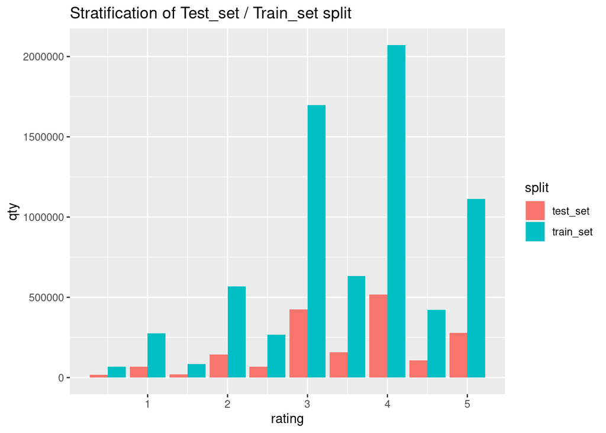

```r
set.seed(1, sample.kind = "Rounding")
test_index <- createDataPartition(edx2$rating,
                                  times = 1,
                                  p = proportionTestSet,
                                  list = FALSE)
test_set <- edx2 %>% slice(test_index)
train_set <- edx2 %>% slice(-test_index)

# remove movies and users from testset that are not present on trainset
test_set <- test_set %>%
  semi_join(train_set, by = "movieId") %>%
  semi_join(train_set, by = "userId")

# check for stratification of train / test split
p1 <- train_set %>%
  group_by(rating) %>%
  summarize(qty = n()) %>%
  mutate(split = 'train_set')

p2 <- test_set %>%
  group_by(rating) %>%
  summarize(qty = n()) %>%
  mutate(split = 'test_set')

p <- bind_rows(p1, p2) %>% group_by(split)
p %>% ggplot(aes(rating, qty, fill = split)) +
  geom_bar(stat="identity", position = "dodge") +
  ggtitle("Stratification of Test_set / Train_set split")
```

```r
# save datasets
train_set %>% write_csv(file = "./dat/train.csv")
test_set  %>% write_csv(file = "./dat/test.csv")
head(train_set)
```

```
##   rating userId movieId yearsFromRelease daysFromFirstUserRating
## 1      5      1     185                4                       0
## 2      5      1     316                4                       0
## 3      5      1     329                4                       0
## 4      5      1     355                4                       0
## 5      5      1     364                4                       0
## 6      5      1     377                4                       0
##   daysFromFirstMovieRating Comedy Romance Action Crime Thriller Drama SciFi
## 1                      153      0       0      1     1        1     0     0
## 2                      154      0       0      1     0        0     0     1
## 3                      154      0       0      1     0        0     1     1
## 4                      154      1       0      0     0        0     0     0
## 5                      154      0       0      0     0        0     1     0
## 6                      154      0       1      1     0        1     0     0
##   Adventure Children Fantasy War Animation Musical Western Mystery FilmNoir
## 1         0        0       0   0         0       0       0       0        0
## 2         1        0       0   0         0       0       0       0        0
## 3         1        0       0   0         0       0       0       0        0
## 4         0        1       1   0         0       0       0       0        0
## 5         1        1       0   0         1       1       0       0        0
## 6         0        0       0   0         0       0       0       0        0
##   Horror Documentary IMAX NoGenre
## 1      0           0    0       0
## 2      0           0    0       0
## 3      0           0    0       0
## 4      0           0    0       0
## 5      0           0    0       0
## 6      0           0    0       0
```

```r
head(test_set)
```

```
##   rating userId movieId yearsFromRelease daysFromFirstUserRating
## 1      5      1     122                4                       0
## 2      5      1     292                4                       0
## 3      5      1     356                4                       0
## 4      5      1     362                4                       0
## 5      5      1     370                4                       0
## 6      5      1     466                4                       0
##   daysFromFirstMovieRating Comedy Romance Action Crime Thriller Drama SciFi
## 1                      123      1       1      0     0        0     0     0
## 2                      150      0       0      1     0        1     1     1
## 3                      154      1       1      0     0        0     1     0
## 4                      154      0       1      0     0        0     0     0
## 5                      154      1       0      1     0        0     0     0
## 6                      154      1       0      1     0        0     0     0
##   Adventure Children Fantasy War Animation Musical Western Mystery FilmNoir
## 1         0        0       0   0         0       0       0       0        0
## 2         0        0       0   0         0       0       0       0        0
## 3         0        0       0   1         0       0       0       0        0
## 4         1        1       0   0         0       0       0       0        0
## 5         0        0       0   0         0       0       0       0        0
## 6         0        0       0   1         0       0       0       0        0
##   Horror Documentary IMAX NoGenre
## 1      0           0    0       0
## 2      0           0    0       0
## 3      0           0    0       0
## 4      0           0    0       0
## 5      0           0    0       0
## 6      0           0    0       0
```

```r
# cleanup memory
rm(edx2, test_index)
rm(p, p1, p2)
```

#### First model: Naive model / Average model

Next, the naive average model is built on top of the trainsetnd its RMSE is presented, as a baseline for the improvement each of next phases will add to the final model.

```r
# predict by global average
print("bias predictions")
```

```
## [1] "bias predictions"
```

```r
mu <- mean(train_set$rating)
predicted <- mu
err <- RMSE(test_set$rating, predicted)
rmse_results <- tibble(model = "naiveAvg",
                       error = err)
rmse_results
```

```
## # A tibble: 1 × 2
##   model    error
##   <chr>    <dbl>
## 1 naiveAvg  1.06
```

#### Second model: Movie bias effect

Secondly, the intuitive effect that a blockbuster film would have on a better rating, regardless of its actual quality, is considered. The resulting model then forecasts the rating as a combination of the naive model and the movie bias model.

```r
# add movie bias effect
df <- train_set %>%
  group_by(movieId) %>%
  summarize(deltaRating = mean(rating - mu))

dfBiasMovie <- left_join(train_set, df) %>%
  select(rating, movieId, deltaRating) %>%
  group_by(movieId) %>%
  summarize(biasMovie = mean(deltaRating))
head(dfBiasMovie)
```

```
## # A tibble: 6 × 2
##   movieId biasMovie
##     <dbl>     <dbl>
## 1       1     0.418
## 2       2    -0.308
## 3       3    -0.371
## 4       4    -0.645
## 5       5    -0.448
## 6       6     0.303
```

```r
df <- left_join(test_set, dfBiasMovie) %>%
  select(rating, movieId, biasMovie)
predicted = mu + df$biasMovie

err <- RMSE(test_set$rating, predicted)
rmse_results <- bind_rows(rmse_results,
                          tibble(model ="movieBias",
                                 error = err))
rmse_results
```

```
## # A tibble: 2 × 2
##   model     error
##   <chr>     <dbl>
## 1 naiveAvg  1.06
## 2 movieBias 0.944
```

#### User bias model

Similarly to the previous case, in this phase the effect of having a given user biased to a given movie is added to the model. The resulting model then forecasts a movie rating as a combination of this model with all previous ones.

```r
# add user bias effect
df <- train_set %>%
  left_join(dfBiasMovie) %>%
  group_by(userId) %>%
  summarize(deltaRating = mean(rating - mu - biasMovie))
dfBiasUser <- left_join(train_set, df) %>%
  select(rating, userId, movieId, deltaRating) %>%
  group_by(userId) %>%
  summarize(biasUser = mean(deltaRating))
head(dfBiasUser)
```

```
## # A tibble: 6 × 2
##   userId biasUser
##    <dbl>    <dbl>
## 1      1    1.65
## 2      2   -0.401
## 3      3    0.243
## 4      4    0.725
## 5      5    0.245
## 6      6    0.370
```

```r
df <- left_join(test_set, dfBiasMovie) %>%
  left_join(dfBiasUser) %>%
  select(rating, movieId, userId, biasMovie, biasUser)
predicted = mu + df$biasMovie + df$biasUser

err <- RMSE(test_set$rating, predicted)
rmse_results <- bind_rows(rmse_results,
                          tibble(model ="userBias",
                                 error = err))
rmse_results
```

```
## # A tibble: 3 × 2
##   model     error
##   <chr>     <dbl>
## 1 naiveAvg  1.06
## 2 movieBias 0.944
## 3 userBias  0.866
```

```r
# cleanup memory
rm(df, predicted)
```

#### Dataset preparation for CNN

- a column named “deltaRating”, which is the result of the actual rating being subtracted by the averages calculated by the three previous models (naive, movie bias, user bias). This column will be used as the outcome for the forthcoming CNN model to predict.
- removal of predictors with small variance, with the aid of the function “nzv” (near zero variance).
- to scale all predictors, in order to ease computational task at the forthcoming CNN analysis.

The below code carries out all these steps and present the modified datasets at a glance:

```r
# prepare trainset
print("pre-process trainset")
```

```
## [1] "pre-process trainset"
```

```r
df_train <- train_set %>%
  select(rating:daysFromFirstMovieRating) %>%
  left_join(dfBiasMovie) %>%
  left_join(dfBiasUser) %>%
  mutate(deltaRating = (rating - mu - biasMovie - biasUser),
         .before = rating) %>%
  select(-c(rating, userId, movieId, biasMovie, biasUser))
# remove predictors with small variance
nzv <- df_train %>%
  select(-deltaRating) %>%
  nearZeroVar(foreach = TRUE, allowParallel = TRUE)

removedPredictors <- colnames(df_train[,nzv])
df_train <- df_train %>% select(-all_of(removedPredictors))

# scale predictors
spec <- feature_spec(df_train, deltaRating ~ . ) %>%
  step_numeric_column(all_numeric(), normalizer_fn = scaler_standard()) %>%
  fit()
spec
```

```
## ── Feature Spec ────────────────────────────────────────────────────────────────
## A feature_spec with 3 steps.
## Fitted: TRUE
## ── Steps ───────────────────────────────────────────────────────────────────────
## The feature_spec has 1 dense features.
## StepNumericColumn: yearsFromRelease, daysFromFirstUserRating, daysFromFirstMovieRating
## ── Dense features ──────────────────────────────────────────────────────────────
```

```r
# prepare testset
print("pre-process testset")
```

```
## [1] "pre-process testset"
```

```r
df_test <- test_set %>%
  select(rating:daysFromFirstMovieRating) %>%
  left_join(dfBiasMovie) %>%
  left_join(dfBiasUser) %>%
  mutate(deltaRating = (rating - mu - biasMovie - biasUser),
         .before = rating) %>%
  select(-c(rating, userId, movieId, biasMovie, biasUser))
df_test <- df_test %>% select(-all_of(removedPredictors))

head(df_train)
```

```
##     deltaRating yearsFromRelease daysFromFirstUserRating
## 1  0.2202001469                4                       0
## 2 -0.0002375475                4                       0
## 3  0.0118478332                4                       0
## 4  0.8605393755                4                       0
## 5 -0.4031922441                4                       0
## 6 -0.1773037655                4                       0
##   daysFromFirstMovieRating
## 1                      153
## 2                      154
## 3                      154
## 4                      154
## 5                      154
## 6                      154
```

```r
head(df_test)
```

```
##    deltaRating yearsFromRelease daysFromFirstUserRating
## 1  0.492535223                4                       0
## 2 -0.063176802                4                       0
## 3 -0.663670202                4                       0
## 4 -0.111627543                4                       0
## 5  0.398999534                4                       0
## 6  0.452096098                4                       0
##   daysFromFirstMovieRating
## 1                      123
## 2                      150
## 3                      154
## 4                      154
## 5                      154
## 6                      154
```

#### Training of CNN model with Tensorflow / Keras

The code presented next takes the necessary steps to configure, compile, train and test the CNN model. As technical reference for designing such model, the reader can refer to the following links:

- https://cran.r-project.org/web/packages/keras/vignettes/index.html
- https://tensorflow.rstudio.com/tutorials/beginners/basic-ml/tutorial_basic_regression/
- https://datascience.stackexchange.com/questions/57171/how-to-improve-low-accuracy-keras-model-design/57292

It is worth to mention that Keras can offer a variety of activation functions for its neurons. However, as the package may consume a significant amount of computer resources, this project will focus only on “Relu” activation function, and will not conduct a grid search among several activation functions. An excellent online lecture about the theory behind neural networks can be found here:

- https://youtu.be/Ih5Mr93E-2c

Please note that the code can take in between 30 min - 1h before it ends at an relatively usual Intel core i7 machine with GPU. At the end, the validation of result on each epoch is presented on a chart. Here is the code:

```r
# wrap the model in a function
print("build keras model")
```

```
## [1] "build keras model"
```

```r
build_model <- function() {
  # create model
  input <- layer_input_from_dataset(df_train %>% select(-deltaRating))

  output <- input %>%
    layer_dense_features(dense_features(spec)) %>%
    layer_dense(units = 8, activation = "relu") %>%
    layer_dense(units = 8, activation = "relu") %>%
    layer_dense(units = 1)

  model <- keras_model(input, output)
  summary(model)

  # compile model
  model %>%
    compile(
      loss = "mse",
      optimizer = optimizer_rmsprop(),
      metrics = list("mean_absolute_error")
    )

  model
}

# train the model
print("train keras model")
```

```
## [1] "train keras model"
```

```r
print_dot_callback <- callback_lambda(
  on_epoch_end = function(epoch, logs) {
    if (epoch %% 80 == 0) cat("\n")
    cat(".")
  }
)

early_stop <- callback_early_stopping(monitor = "val_loss",
                                      min_delta = 1e-5,
                                      patience = 5)

model <- build_model()
```

```
## Model: "model"
## ________________________________________________________________________________
## Layer (type)              Output Shape      Param #  Connected to
## ================================================================================
## daysFromFirstMovieRating  [(None,)]         0
## ________________________________________________________________________________
## daysFromFirstUserRating ( [(None,)]         0
## ________________________________________________________________________________
## yearsFromRelease (InputLa [(None,)]         0
## ________________________________________________________________________________
## dense_features (DenseFeat (None, 3)         0        daysFromFirstMovieRating[0]
##                                                      daysFromFirstUserRating[0][
##                                                      yearsFromRelease[0][0]
## ________________________________________________________________________________
## dense_2 (Dense)           (None, 8)         32       dense_features[0][0]
## ________________________________________________________________________________
## dense_1 (Dense)           (None, 8)         72       dense_2[0][0]
## ________________________________________________________________________________
## dense (Dense)             (None, 1)         9        dense_1[0][0]
## ================================================================================
## Total params: 113
## Trainable params: 113
## Non-trainable params: 0
## ________________________________________________________________________________
```

```r
history <- model %>% fit(
  x = df_train %>% select(-deltaRating),
  y = df_train$deltaRating,
  epochs = numberOfEpochs,
  validation_split = 0.2,
  verbose = 0,
  callbacks = list(early_stop, print_dot_callback)
)
```

```
##
## .........
```

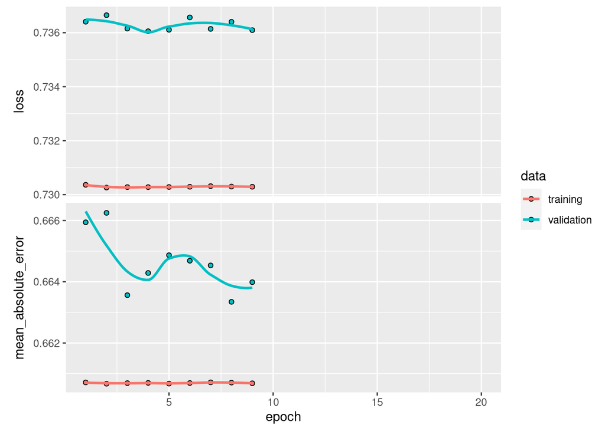

```r
plot(history)
```

At the end, the CNN model is combined with the previous models and used to predict the results on the testset, with an outcome RMSE result at around 0.865.

```r
# predict
print("predict testset results")
```

```
## [1] "predict testset results"
```

```r
p <- model %>% predict(df_test %>% select(-deltaRating))
p <- p[ , 1]

df <- test_set %>%
  select(userId, movieId) %>%
  left_join(dfBiasMovie) %>%
  left_join(dfBiasUser) %>%
  mutate(predicted = mu + biasMovie + biasUser + p)
# calculate error metrics
err <- errRMSE(test_set$rating, df$predicted)

rmse_results <- bind_rows(rmse_results,
                          tibble(model ="keras",
                                 error = err))

# show RMSE results
rmse_results
```

```
## # A tibble: 4 × 2
##   model     error
##   <chr>     <dbl>
## 1 naiveAvg  1.06
## 2 movieBias 0.944
## 3 userBias  0.866
## 4 keras     0.865
```

```r
# clean memory
rm(df, df_train, df_test, p)
```

### Validation: The Final Step

Given that we have a tested model, it is time to validate it. The “validation” dataset is now recovered and pre-processed for use, then the predictions are made over it. It is worth to note that the RMSE result is slightly higher than the previous prediction with the testset, which is a good indication of model generality.

```r
# validation
# read dataset from csv
print("predict validation results")
```

```
## [1] "predict validation results"
```

```r
validation <- read_csv(file = "./dat/validation.csv") %>% as_tibble()
head(validation)
```

```
## # A tibble: 6 × 6
##   userId movieId rating timestamp title                      genres
##    <dbl>   <dbl>  <dbl>     <dbl> <chr>                      <chr>
## 1      1     231      5 838983392 Dumb & Dumber (1994)       Comedy
## 2      1     480      5 838983653 Jurassic Park (1993)       Action|Adventure|S…
## 3      1     586      5 838984068 Home Alone (1990)          Children|Comedy
## 4      2     151      3 868246450 Rob Roy (1995)             Action|Drama|Roman…
## 5      2     858      2 868245645 Godfather, The (1972)      Crime|Drama
## 6      2    1544      3 868245920 Lost World: Jurassic Park… Action|Adventure|H…
```

```r
validation <- validation %>%
  semi_join(train_set, by = "movieId") %>%
  semi_join(train_set, by = "userId")

df_val <- validation %>%
  select(-c(genres)) %>%
  mutate(yearOfRelease = as.numeric(stringi::stri_sub(validation$title[1], -5, -2)),
         timestampYear = year(as_datetime(timestamp)),
         yearsFromRelease = timestampYear - yearOfRelease) %>%
  select(-c(rating, title, yearOfRelease, timestampYear)) %>%
  left_join(dfFirstMovieRating) %>%
  left_join(dfFirstUserRating) %>%
  mutate(daysFromFirstUserRating  = daysBetweenTimestamps(timestamp, firstUserRating),
         daysFromFirstMovieRating = daysBetweenTimestamps(timestamp, firstMovieRating)) %>%
  select(-c(userId, movieId, timestamp, firstUserRating,firstMovieRating))
head(df_val)
```

```
## # A tibble: 6 × 3
##   yearsFromRelease daysFromFirstUserRating daysFromFirstMovieRating
##              <dbl>                   <dbl>                    <dbl>
## 1                2                       0                      154
## 2                2                       0                      154
## 3                2                       0                       73
## 4                3                       0                      489
## 5                3                       0                      325
## 6                3                       0                       46
```

```r
p <- model %>% predict(df_val)
p <- p[ , 1]

df <- validation %>%
  left_join(dfBiasMovie) %>%
  left_join(dfBiasUser) %>%
  mutate(predicted = mu + biasMovie + biasUser + p)
err <- errRMSE(validation$rating, df$predicted)

rmse_results <- bind_rows(rmse_results,
                          tibble(model ="validation",
                                 error = err))

# show RMSE results
print("project results")
```

```
## [1] "project results"
```

```r
rmse_results
```

```
## # A tibble: 5 × 2
##   model      error
##   <chr>      <dbl>
## 1 naiveAvg   1.06
## 2 movieBias  0.944
## 3 userBias   0.866
## 4 keras      0.865
## 5 validation 0.866
```

```r
err
```

```
## [1] 0.86609467
```

```r
# clean memory
rm(df, df_test, df_val)
rm(train_set, test_set, validation)

# restore warnings
print("job done")
```

```
## [1] "job done"
```

```r
options(warn = oldw)
```